# Assignment 3

Maryam Hasanzadehkiabi

## Insert and running required packages

```r
if (!requireNamespace("rmarkdown", quietly = TRUE))
    +     install.packages("rmarkdown")
if (!requireNamespace("knitr", quietly = TRUE))
    +     install.packages("knitr")
if (!requireNamespace("devtools", quietly = TRUE))
    +     install.packages("devtools")
if (!requireNamespace("BiocManager", quietly = TRUE))
    +     install.packages("BiocManager")
if (!requireNamespace("edgeR", quietly = TRUE))
    BiocManager::install("edgeR")
if (!requireNamespace("biomaRt", quietly = TRUE))
    BiocManager::install("biomaRt")
if (!requireNamespace("GEOmetadb", quietly = TRUE))
    BiocManager::install("GEOmetadb")
if (!requireNamespace("GEOquery", quietly = TRUE))
    +     install.packages("GEOquery")
if (!requireNamespace("DBI", quietly = TRUE))
    +     install.packages("DBI")
if (!requireNamespace("RSQLite", quietly = TRUE))
    +     install.packages("RSQLite")
if(!requireNamespace("kableExtra", quietly=TRUE))
    install.packages("kableExtra")
if (!requireNamespace("RCurl", quietly = TRUE))
    +     install.packages("RCurl")
if (!requireNamespace("RCy3", quietly = TRUE))
    +     install.packages("RCy3")
if (!requireNamespace("ggplot2", quietly = TRUE))
    +     install.packages("ggplot2")
```

```r
library(devtools)
library(rmarkdown)
library(knitr)
library(BiocManager)
library(GEOmetadb)
library(GEOquery)
library(DBI)
library(RSQLite)
library(edgeR)
library(biomaRt)
library(kableExtra)
library(RCurl)
library(RCy3)
library(ggplot2)
```

# Non-thresholded Gene set Enrichment Analysis

**1. What method did you use? What genesets did you use? Make sure to specify versions and cite your methods.**

1. “GSEA v4.3.2” was used to perform non-thresholded gene set enrichment analysis<sup>20</sup>,<sup>21</sup>.
2. “Human_GOBP_AllPathways_no_GO_iea_April_02_2023_symbol.gmt” was downloaded manually from the Bader lab, and used as genesets.
3. CRC_ranked_genelist.rank from assignment 2, was used as the ranked list. Other parameters include: number of permutations: 1,000; No_Collapse; Max size: 200; and Min size: 15.

**2. Summarize your enrichment results.**

The GSEA report is presented in Figure 1. Filtering (min: 15, max:200) results in 3,945 gene sets that are included in the analysis.

**Figure 1. GSEA Report Summary**

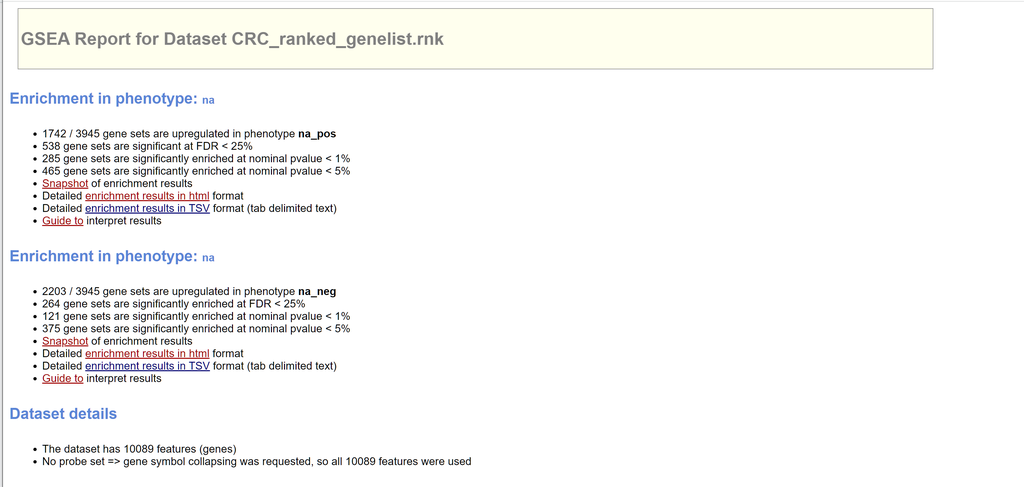

In the following sections, the top 5 pathways in each group (controls versus TreatmentA) are summarized in Table 1 and Table 2.

```r
controls_g <- read.delim("/Users/maryamhasanzadehkiabi/Documents/BCB420/Maryam_Hasanzadehkiabi/Assignment 3/result_data/control_vs_treatmentA.GseaPreranked.1680983057326/gsea_report_for_na_pos_1680983057326.tsv", header = TRUE)

controls_g <- controls_g[, !(names(controls_g) %in% c("GS.br..follow.link.to.MSigDB", "GS.DETAILS", "X"))]
kable(head(controls_g, n = 5), type="html", caption = "Table 1. Top 5 positive enrichment GSEA results for controls", row.names = FALSE) %>%
  kable_styling()
```

Table 1. Top 5 positive enrichment GSEA results for controls

| NAME | SIZE | ES | NES | NOM.p.val | FDR.q.val | FWER.p.val | RANK.AT.MAX | LEADING.EDGE |
| --- | --- | --- | --- | --- | --- | --- | --- | --- |
| RIBONUCLEOPROTEIN COMPLEX BIOGENESIS%GOBP%GO:0022613 | 119 | 0.7678806 | 2.463008 | 0 | 0 | 0 | 1482 | tags=69%, list=15%, signal=80% |
| METABOLISM OF RNA%REACTOME DATABASE ID RELEASE 83%8953854 | 193 | 0.7146996 | 2.380743 | 0 | 0 | 0 | 1766 | tags=59%, list=18%, signal=70% |
| RIBOSOME BIOGENESIS%GOBP%GO:0042254 | 67 | 0.8008034 | 2.375817 | 0 | 0 | 0 | 1386 | tags=82%, list=14%, signal=95% |
| HALLMARK_MYC_TARGETS_V1%MSIGDBHALLMARK%HALLMARK_MYC_TARGETS_V1 | 49 | 0.8327414 | 2.307083 | 0 | 0 | 0 | 1520 | tags=84%, list=15%, signal=98% |
| RRNA PROCESSING%GOBP%GO:0006364 | 42 | 0.8379325 | 2.270279 | 0 | 0 | 0 | 1386 | tags=88%, list=14%, signal=102% |

```r
treatmentA_g <- read.delim("/Users/maryamhasanzadehkiabi/Documents/BCB420/Maryam_Hasanzadehkiabi/Assignment 3/result_data/control_vs_treatmentA.GseaPreranked.1680983057326/gsea_report_for_na_neg_1680983057326.tsv", header = TRUE)

treatmentA_g <- treatmentA_g[, !(names(controls_g) %in% c("GS.br..follow.link.to.MSigDB", "GS.DETAILS", "X"))]
kable(head(treatmentA_g, n = 5), type="html", caption = "Table 2. Top 5 Negative enrichment GSEA results for treatmentA", row.names = FALSE) %>%
  kable_styling()
```

Table 2. Top 5 Negative enrichment GSEA results for treatmentA

| NAME | GS.br..follow.link.to.MSigDB | GS.DETAILS | SIZE | ES | NES | NOM.p.val | FDR.q.val | FWER.p.val | RANK.AT.MAX | LEADING.EDGE | X |
| --- | --- | --- | --- | --- | --- | --- | --- | --- | --- | --- | --- |
| DEFENSINS%REACTOME DATABASE ID RELEASE 83%1461973 | DEFENSINS%REACTOME DATABASE ID RELEASE 83%1461973 | Details ... | 38 | -0.8799209 | -2.202260 | 0 | 0.0000000 | 0.000 | 271 | tags=8%, list=3%, signal=8% | NA |
| NEUTRAL LIPID CATABOLIC PROCESS%GOBP%GO:0046461 | NEUTRAL LIPID CATABOLIC PROCESS%GOBP%GO:0046461 | Details ... | 16 | -0.8749032 | -1.861763 | 0 | 0.0483222 | 0.098 | 839 | tags=44%, list=8%, signal=48% | NA |
| ACYLGLYCEROL CATABOLIC PROCESS%GOBP%GO:0046464 | ACYLGLYCEROL CATABOLIC PROCESS%GOBP%GO:0046464 | Details ... | 16 | -0.8749032 | -1.827875 | 0 | 0.0868934 | 0.245 | 839 | tags=44%, list=8%, signal=48% | NA |
| ANTIMICROBIAL PEPTIDES%REACTOME DATABASE ID RELEASE 83%6803157 | ANTIMICROBIAL PEPTIDES%REACTOME DATABASE ID RELEASE 83%6803157 | Details ... | 59 | -0.6859221 | -1.824699 | 0 | 0.0691738 | 0.255 | 405 | tags=7%, list=4%, signal=7% | NA |
| ARACHIDONIC ACID METABOLISM%REACTOME DATABASE ID RELEASE 83%2142753 | ARACHIDONIC ACID METABOLISM%REACTOME DATABASE ID RELEASE 83%2142753 | Details ... | 40 | -0.7261553 | -1.823822 | 0 | 0.0553391 | 0.255 | 430 | tags=20%, list=4%, signal=21% | NA |

```r
NA
```

**3. How do these results compare to the results from the thresholded analysis in Assignment #2. Compare qualitatively. Is this a straight forward comparison? Why or why not?**

In the assignment 2, g:Profiler reports separately for up-regulated and down-regulated gene list, how genes are differentially expressed. While in GSEA, a ranked gene list including both up-regulated and down-regulated genes is used to get genes expression.

g:Profiler detected 8 pathways annotated by GO:BP, 3 pathways annotated by Reactome, and non annotated by WikiPathways in up-regulated genes, the top one of each is listed below:  
protein folding (GO:00064574) PERK regulates gene expression (REAC:R-HSA-381042) With respect to the down-regulated genes, no results was returned by g:Profiler.

The top pathway detected by GSEA is RIBONUCLEOPROTEIN COMPLEX BIOGENESIS (GO:0022613) in control group, and DEFENSINS%REACTOME DATABASE (ID RELEASE 1461973) in TreatmentA group.

Since the input and output files are different in each method (g:Profiler vs GSEA), they could not be compared easily.

# Visualize your Gene set Enrichment Analysis in Cytoscape

**1. Create an enrichment map - how many nodes and how many edges in the resulting map? What thresholds were used to create this map? Make sure to record all thresholds. Include a screenshot of your network prior to manual layout.**

Cytoscope v3.9.1 was used to create enrichment map<sup>22</sup>,<sup>23</sup>,<sup>24</sup>.

A screenshot is displayed below.

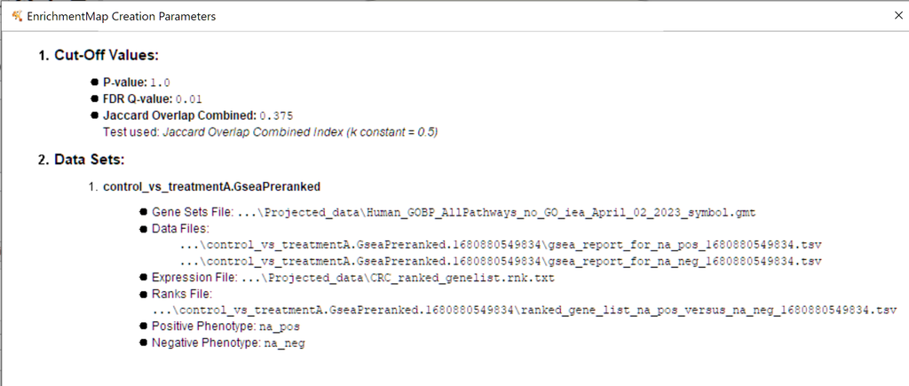

```r
gmt_url = "http://download.baderlab.org/EM_Genesets/current_release/Human/symbol/"
```

```r
filenames = getURL(gmt_url)
tc = textConnection(filenames)
```

```
Found more than one class "textConnection" in cache; using the first, from namespace 'BiocGenerics'
Also defined by ‘RJSONIO’
```

```r
contents = readLines(tc)
close(tc)
```

```r
rx = gregexpr("(?<=<a href=\")(.*.GOBP_AllPathways_no_GO_iea.*.)(.gmt)(?=\">)", contents,
    perl = TRUE)
gmt_file = unlist(regmatches(contents, rx))
dest_gmt_file <- file.path("/Users/maryamhasanzadehkiabi/Documents/BCB420/Maryam_Hasanzadehkiabi/Assignment 3/data_dir", gmt_file)
download.file(paste(gmt_url, gmt_file, sep = ""), destfile = dest_gmt_file)
```

```r
gsea_jar <- "/Users/maryamhasanzadehkiabi/Documents/BCB420/Maryam_Hasanzadehkiabi/Assignment 3/GSEA_4.3.2/gsea-cli.sh"
java_version <- 12
run_gsea = "/Users/maryamhasanzadehkiabi/Documents/BCB420/Maryam_Hasanzadehkiabi/Assignment 3/GSEA_4.3.2/gsea.sh"

working_directory = setwd("/Users/maryamhasanzadehkiabi/Documents/BCB420/Maryam_Hasanzadehkiabi/Assignment 3/result_data/control_vs_treatmentA.GseaPreranked.1680983057326")
gsea_directory = paste(working_directory,"control_vs_treatmentA.GseaPreranked.1680983057326", sep = "/")

analysis_name <- "/Users/maryamhasanzadehkiabi/Documents/BCB420/Maryam_Hasanzadehkiabi/Assignment 3/result_data/control_vs_treatmentA.GseaPreranked.1680983057326/control_vs_treatmentA.GseaPreranked.1680983057326.rpt"

rank_file <- "/Users/maryamhasanzadehkiabi/Documents/BCB420/Maryam_Hasanzadehkiabi/Assignment 3/result_data/control_vs_treatmentA.GseaPreranked.1680983057326/ranked_gene_list_na_pos_versus_na_neg_1680983057326.tsv"

espression_file <- "/Users/maryamhasanzadehkiabi/Documents/BCB420/Maryam_Hasanzadehkiabi/Assignment 3/project_data/CRC_ranked_genelist.rnk"

command <- paste("java  -Xmx1G -cp",gsea_jar,  "xtools.gsea.GseaPreranked -gmx", dest_gmt_file, "-rnk" ,file.path(working_directory,rank_file), "-collapse false -nperm 1000 -permute gene_set -scoring_scheme weighted -rpt_label ",analysis_name,"  -num 100 -plot_top_x 20 -rnd_seed 12345  -set_max 200 -set_min 15 -zip_report false -out" ,working_directory, "-gui false > gsea_output.txt",sep=" ")

gsea_output_dir <- gsea_directory

cytoscapePing()
```

```
You are connected to Cytoscape!
```

```r
cytoscapeVersionInfo()
```

```
      apiVersion cytoscapeVersion
            "v1"          "3.9.1"
```

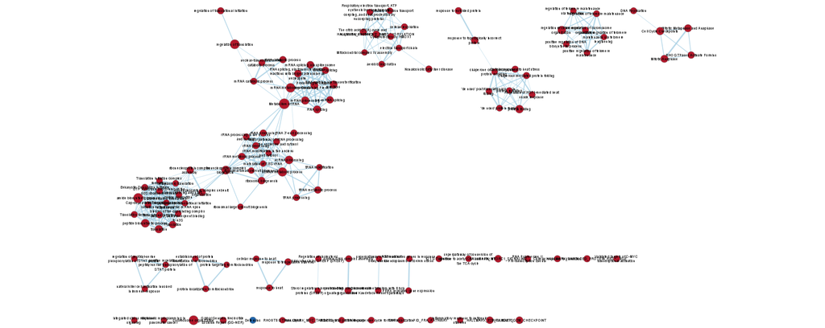

```r
pvalue_gsea_threshold <- "0.05"
qvalue_gsea_threshold <- "0.01"
similarity_threshold <- "0.375"
similarity_metric = "COMBINED"
cur_model_name <- analysis_name
gsea_results_path <- file.path(gsea_output_dir,"edb")
gsea_results_filename <- file.path(gsea_results_path,"results.edb")

gmt_gsea_file <- file.path(getwd(),dest_gmt_file)
gsea_ranks_file <- file.path(gsea_results_path,list.files(gsea_results_path,pattern=".rnk"))


current_network_name <- paste(cur_model_name,pvalue_gsea_threshold,qvalue_gsea_threshold,sep="_")
em_command = paste('enrichmentmap build analysisType="gsea" gmtFile=',gmt_gsea_file,
                   'pvalue=',pvalue_gsea_threshold, 'qvalue=',qvalue_gsea_threshold,
                   'similaritycutoff=',similarity_threshold,
                   'coefficients=',similarity_metric,'ranksDataset1=',
                   gsea_ranks_file,'enrichmentsDataset1=',gsea_results_filename,
                   'filterByExpressions=false',
                   'expressionDataset1=',file.path(getwd(),working_directory,espression_file),
                   sep=" ")



knitr::include_graphics("/Users/maryamhasanzadehkiabi/Documents/BCB420/Maryam_Hasanzadehkiabi/Assignment 3/result_data/initial_screenshot_network.png")
```

```r
#response <- commandsGET(em_command)
#current_network_suid <- 0


#current_names <- getNetworkList()
#output_network_file <- file.path(getwd(),"initial_screenshot_network.png")
#response <- exportImage(output_network_file, type = "png")

#htmltools::img(src = knitr::image_uri(output_network_file),
#               alt = 'Initial Enrichment Map',
#               style = 'margin:0px auto;display:block')
```

**2. Annotate your network - what parameters did you use to annotate the network. If you are using the default parameters make sure to list them as well.**

An AutoAnnotated output was created and is displayed below (screen shot).

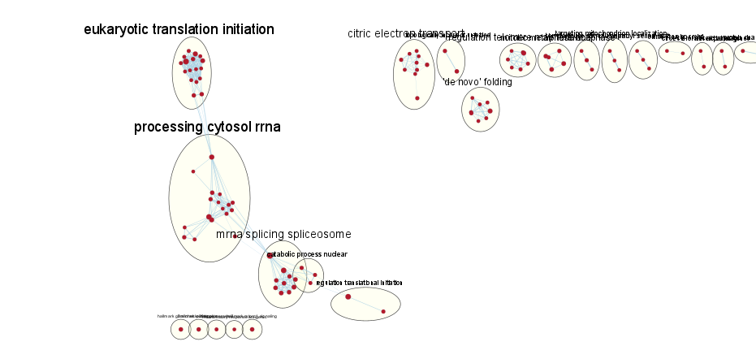

**3. Make a publication ready figure - include this figure with proper legends in your notebook.**

Another annotation using parameters as Cluster algorithm: MCL Cluster, Edge weight column: similarity_coefficient, singleton clusters, prevent cluster overlap, Lable column: GS_DESCR, Lable algorithm: WordCloud (Adjacent Words), max words: 3, min word: 1, Adjacent word: 8, was performed and the screen shot is shown below

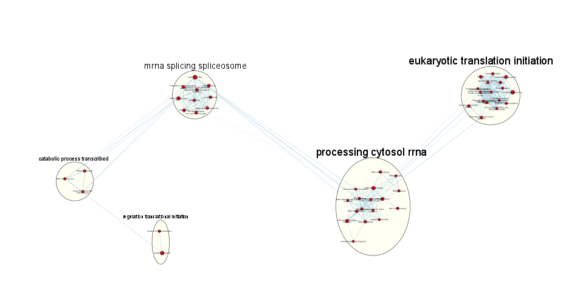

**4. Collapse your network to a theme network. What are the major themes present in this analysis? Do they fit with the model? Are there any novel pathways or themes?**

By using filter in control panel, a sub-network was created. The new sub-network includes 2 clusters rRNA processing cytosol that contains 22 genes, and RNA 3’ end that contains 2 genes. It is displayed below

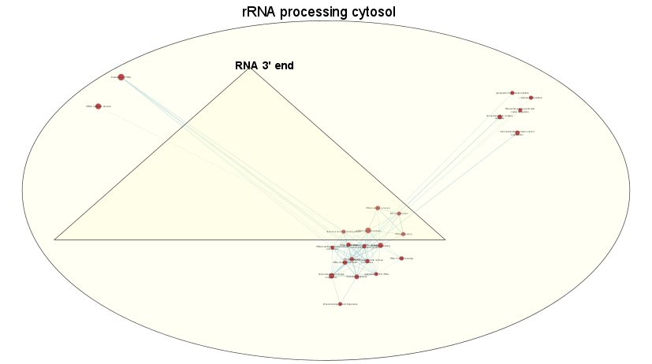

# Interpretation and detailed view of results

**1. Do the enrichment results support conclusions or mechanism discussed in the original paper? How do these results differ from the results you got from Assignment #2 thresholded methods**

I could not get even close results to what the primary investigators indicated in the original article.

**2. Can you find evidence, i.e. publications, to support some of the results that you see. How does this evidence support your result?**

**1. Add a post analysis to your main network using specific transcrip”on factors, microRNAs or drugs. Include the reason why you chose the specific miRs, TFs or drugs (i.e publications indicating that they might be related to your model). What does this post analysis show?**

Since the main study was conducted to determine the effect of some drugs on different groups of colon cancer<sup>25</sup>, a post analysis using drugs was performed over the network. Human_DrugBank_all_symbol was downloaded and used as signature gene sets. Some drugs such as COPPER, CHOLIC ACID, GELDANAMYCIN, and ARTENIMOL were found as significantly interacted with different genes and pathways in the study (screenshot is provided below). There are few studies that provide supports for these substances in the treatment of cancers<sup>26</sup>,<sup>27</sup>,<sup>28</sup>,<sup>29</sup>.

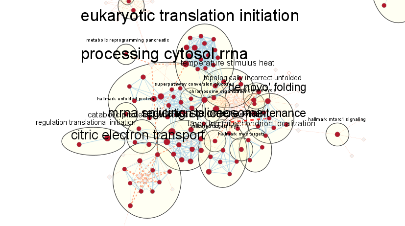

# References

1.

Xie Y, Allaire JJ, Grolemund G. *R Markdown: The Definitive Guide*. Chapman; Hall/CRC; 2018.

2.

Allaire J, Xie Y, McPherson J, et al. Rmarkdown: Dynamic documents for r. R package version 2.20.1. 2023.

3.

Xie Y, Dervieux C, Riederer E. *R Markdown Cookbook*. Chapman; Hall/CRC; 2020.

4.

Zhu H. *kableExtra: Construct Complex Table with ’Kable’ and Pipe Syntax*.; 2021. https://CRAN.R-project.org/package=kableExtra.

5.

Müller K, Wickham H, James DA, Falcon S. *RSQLite: SQLite Interface for r*.; 2023.

6.

R Special Interest Group on Databases (R-SIG-DB), Wickham H, Müller K. *DBI: R Database Interface*.; 2022.

7.

Davis S, Meltzer P. GEOquery: A bridge between the gene expression omnibus (GEO) and BioConductor. *Bioinformatics*. 2007;14:1846-1847.

8.

Morgan M. *BiocManager: Access the Bioconductor Project Package Repository*.; 2022. https://CRAN.R-project.org/package=BiocManager.

9.

Zhu Y, Davis S, Stephens R, Meltzer PS, Chen Y. GEOmetadb: Powerful alternative search engine for the gene expression omnibus. *Bioinformatics*. 2008;24(23):2798-2800.

10.

Durinck S, Spellman PT, Birney E, Huber W. Mapping identifiers for the integration of genomic datasets with the r/bioconductor package biomaRt. *Nature protocols*. 2009;4(8):1184-1191.

11.

Durinck S, Moreau Y, Kasprzyk A, et al. BioMart and bioconductor: A powerful link between biological databases and microarray data analysis. *Bioinformatics*. 2005;21(16):3439-3440.

12.

Drost H-G, Paszkowski J. Biomartr: Genomic data retrieval with r. *Bioinformatics*. 2017;33(8):1216-1217.

13.

Loraine AE, Blakley IC, Jagadeesan S, Harper J, Miller G, Firon N. Analysis and visualization of RNA-seq expression data using RStudio, bioconductor, and integrated genome browser. *Plant Functional Genomics: Methods and Protocols*. 2015:481-501.

14.

Robinson MD, McCarthy DJ, Smyth GK. edgeR: A bioconductor package for differential expression analysis of digital gene expression data. *bioinformatics*. 2010;26(1):139-140.

15.

Wickham H, Hester J, Chang W, Bryan J. *Devtools: Tools to Make Developing r Packages Easier*.; 2022.

16.

Dervieux C. *Pandoc: Manage and Run Universal Converter ’Pandoc’ from ’r’*.; 2022.

17.

Xie Y. *Knitr: A General-Purpose Package for Dynamic Report Generation in r*.; 2023. https://yihui.org/knitr/.

18.

Xie Y. *Dynamic Documents with R and Knitr*. 2nd ed. Boca Raton, Florida: Chapman; Hall/CRC; 2015. https://yihui.org/knitr/.

19.

Xie Y. Knitr: A comprehensive tool for reproducible research in R. In: Stodden V, Leisch F, Peng RD, eds. *Implementing Reproducible Computational Research*. Chapman; Hall/CRC; 2014.

20.

Subramanian A, Tamayo P, Mootha VK, et al. Gene set enrichment analysis: A knowledge-based approach for interpreting genome-wide expression profiles. *Proceedings of the National Academy of Sciences*. 2005;102(43):15545-15550.

21.

Mootha VK, Lindgren CM, Eriksson K-F, et al. PGC-1$\alpha$-responsive genes involved in oxidative phosphorylation are coordinately downregulated in human diabetes. *Nature genetics*. 2003;34(3):267-273.

22.

Shannon P, Markiel A, Ozier O, et al. Cytoscape: A software environment for integrated models of biomolecular interaction networks. *Genome research*. 2003;13(11):2498-2504.

23.

Otasek D, Morris JH, Bouças J, Pico AR, Demchak B. Cytoscape automation: Empowering workflow-based network analysis. *Genome biology*. 2019;20:1-15.

24.

Reimand J, Isserlin R, Voisin V, et al. Pathway enrichment analysis and visualization of omics data using g: Profiler, GSEA, cytoscape and EnrichmentMap. *Nature protocols*. 2019;14(2):482-517.

25.

Schmidt EM, Lamprecht S, Blaj C, et al. Targeting tumor cell plasticity by combined inhibition of NOTCH and MAPK signaling in colon cancer. *Journal of experimental medicine*. 2018;215(6):1693-1708.

26.

Ni Q, Zhao J, Gao Y, Qin D, Chen X, Ainiwaer X. Prediction of potential drugs and targets based on meibomian gland dysfunction module classification to guide individualized treatment. *Journal of Cellular Biochemistry*. 2019;120(9):14813-14821.

27.

Barka EA, Vatsa P, Sanchez L, et al. Taxonomy, physiology, and natural products of actinobacteria. *Microbiology and molecular biology reviews*. 2016;80(1):1-43.

28.

Sung D-B, Lee JS. Natural-product-based fluorescent probes: Recent advances and applications. *RSC Medicinal Chemistry*. 2023.

29.

Hammood M, Guérin B, Leyton J, Tai L-H. ASSESS THE CYTOTOXIC EFFECT OF NOVEL ANTI-HER2 ADCS IN AN IN VITRO MODEL OF RESISTANT BREAST CANCER. 2021.